# Data Analysis - Capstone Project JHU

### Synopsis

The capstone project is about creating a next word typing prediction application. For the capstone project we have been provided a data from a corpus called HC Corpora http://www.corpora.heliohost.org). The data will be used to create a predictive algorithm. In order to build the algorithm it is required to perform data analysis. This document covers the steps taken.

#### Load libraries

```r
library(NLP)
library(tm)
library(knitr)
library(ggplot2)
library(wordcloud)
library(RWeka)
library(RColorBrewer)
library(SnowballC)
```

### Data Processing

Data for the capstone can be found here. https://d396qusza40orc.cloudfront.net/dsscapstone/dataset/Coursera-SwiftKey.zip

```r
data_directory="~/Documents/coursera/DSCapstone/final"
# The source and destination of the data set

if(!file.exists(data_directory)){
    destination_file <- "Coursera-SwiftKey.zip"
    source_file <- "https://d396qusza40orc.cloudfront.net/dsscapstone/dataset/Coursera-SwiftKey.zip"

    # Get the data set
    download.file(source_file, destination_file,method="curl")

    # extract the data
    unzip(destination_file)
}
```

Corpus has data provided in four languages. As per the assignment we will focus on en_US data set. The Corpora are contained in three seperate plain text `.txt` files. Load the data for analysis.

```r
if(!file.exists("./milestoneReport/fileSummary.rds")){
    twitter <- readLines("final/en_US/en_US.twitter.txt", encoding = "UTF-8",skipNul=TRUE)
    blogs <- readLines("final/en_US/en_US.blogs.txt",encoding = "UTF-8",skipNul=TRUE)
    news <- readLines("final/en_US/en_US.news.txt", encoding = "UTF-8",skipNul=TRUE)

    set.seed(8534)
    sampleTwitter <- twitter[sample(1:length(twitter),5000)]
    sampleNews <- news[sample(1:length(news),5000)]
    sampleBlogs <- blogs[sample(1:length(blogs),5000)]
    sample <- c(sampleTwitter,sampleNews,sampleBlogs)
    writeLines(sample, "./milestoneReport/sample.txt")

    sample <- readLines("./milestoneReport/sample.txt", encoding = "UTF-8",skipNul=TRUE)
    twitterSize <- round(file.info("final/en_US/en_US.twitter.txt")$size / 1024.0 ^ 2, digits=2)
    blogsSize <- round(file.info("final/en_US/en_US.blogs.txt")$size / 1024.0 ^ 2, digits=2)
    newsSize <- round(file.info("final/en_US/en_US.news.txt")$size / 1024.0 ^ 2, digits=2)
    sampleSize <- round(file.info("milestoneReport/sample.txt")$size / 1024.0 ^ 2, digits=2)

    twitterLength <- round(length(twitter)/1000,digits=0)
    blogsLength <- round(length(blogs)/1000,digits=0)
    newsLength <- round(length(news)/1000,digits=0)
    sampleLength <- round(length(sample)/1000,digits=0)

    twitterWords <- round(sum(sapply(gregexpr("\\S+", twitter), length))/1000,digits=0)
    blogsWords <- round(sum(sapply(gregexpr("\\S+", blogs), length))/1000,digits=0)
    newsWords <- round(sum(sapply(gregexpr("\\S+", news), length))/1000,digits=0)
    sampleWords <- round(sum(sapply(gregexpr("\\S+", sample), length))/1000,digits=0)

    fileSummary <- data.frame(
            fileName = c("Twitter","Blog","News", "Sample"),
            fileSize = c(twitterSize,blogsSize,newsSize,sampleSize),
            lineCount = c(twitterLength,blogsLength,newsLength,sampleLength),
            wordCount = c(twitterWords, blogsWords, newsWords, sampleWords)
    )
    colnames(fileSummary) <- c("File Name", "File Size (MB)", "Line Count (Thousands)", "Word Count (Thousands)")
    saveRDS(fileSummary, file = "./milestoneReport/fileSummary.rds")
}
fileSummaryDF <- readRDS("./milestoneReport/fileSummary.rds")
knitr::kable(head(fileSummaryDF, 10))
```

| File Name | File Size (MB) | Line Count (Thousands) | Word Count (Thousands) |
| --- | --- | --- | --- |
| Twitter | 159.36 | 2360 | 30374 |
| Blog | 200.42 | 899 | 37334 |
| News | 196.28 | 1010 | 34373 |
| Sample | 2.37 | 15 | 435 |

As observed from above the files are around 200 MB per file. Blogs and News corpora consists of about 1 million items each, and twitter consists of about 2 million items. Since Twitter messages have a character limit of 140 Character, this explains the reason there are so many more items.

### Cleaning and building Corpus

For performing the predictive model we need to application to be void of certain cases. The goal is to get to clean data set that will help us achieve our final goal. We will use `tm` https://cran.r-project.org/web/packages/tm/index.html package to make the work easier of text mining.

The following cleanups will be performed. 1. Lower case 2. Remove puntuation 3. Remove numbers 4. Remove White Space

For predicting the next word, it is not very useful if we have to predit “See you at 8”, not having numbers is going to help with the scenario. Our model can’t predict it, and won’t help the user.

Stop words: Based on research of various articles it is clear that removing stop words would be counter productive and would change the meaning completely. We start the analysis without using stop words and prove that it is the correct anlysis.

```r
if(!file.exists("./milestoneReport/clean.rds")){
    sample <- readLines("./milestoneReport/sample.txt", encoding = "UTF-8",skipNul=TRUE)
    sample.corpus <- VCorpus(VectorSource(sample))
    sample.corpus <- tm_map(sample.corpus, stripWhitespace) #stripWhitespace: eliminate extra white-spaces
    sample.corpus <- tm_map(sample.corpus, removeNumbers) #removeNumber: remove numbers
    removeMostPunctuation<-function (x) {
                x <- gsub("[^ a-z0-9'-]", " ", x)
                x <- gsub("(\\w)-(\\w)", "\\1\1\\2", x)
                x <- gsub("(\\w)'(\\w)", "\\1\2\\2", x)
                x <- gsub("[[:punct:]]+", "", x)
                x <- gsub("\1", "-", x, fixed = TRUE)
                x <- gsub("\2", "'", x, fixed = TRUE)
                gsub("^'|-", "", x)
        } # remove all punctuations except intra-word-dashes and inta-word-apostrophes
    sample.corpus <- tm_map(sample.corpus, content_transformer(removeMostPunctuation)) #custom implementation to remove punctuations
    sample.corpus <- tm_map(sample.corpus, tolower, lazy=TRUE) #tolower: convert text to lower case
    sample.corpus <- tm_map(sample.corpus, PlainTextDocument)
    sample.corpus <- tm_map(sample.corpus, stemDocument)
    #stemming is applied to documents to remove common words endings for English words, such as "es", "ed" and "s".
    clean.corpus <- Corpus(VectorSource(sample.corpus))
    #required to reload the class to avoid errors with DocumentTermMatrix
    rm(sample.corpus)
    saveRDS(clean.corpus, file="./milestoneReport/clean.rds")
    #tdm <- TermDocumentMatrix(clean.corpus)
    #saveRDS(tdm, file="./milestoneReport/tdm.rds")
}
```

### Exploratory Analysis

In NLP one of the most common method is N-grams. N-grams allows to create a model where a words likelihood is determined by the previous words. An N-Gram of one word is called unigram, two words is bigrams …

```r
if(!file.exists("./milestoneReport/trigram.rds")){

con <- gzfile("./milestoneReport/clean.rds")
corpus <- readRDS(con)
close(con)
corpus_df <-data.frame(text=unlist(sapply(corpus,`[`, "content")), stringsAsFactors = FALSE)

# Function for nGram
ngramTokenizer <- function(theCorpus, ngramCount) {
  ngramFunction <- NGramTokenizer(theCorpus,
                                  Weka_control(min = ngramCount, max = ngramCount,
                                               delimiters = " \\r\\n\\t.,;:\"()?!"))
  ngramFunction <- data.frame(table(ngramFunction))
  ngramFunction <- ngramFunction[order(ngramFunction$Freq,
                                       decreasing = TRUE),]
  colnames(ngramFunction) <- c("String","Count")
  ngramFunction
}


# Generate unigrams and save
unigrams <- ngramTokenizer(corpus_df, 1)
saveRDS(unigrams, file = "./milestoneReport/unigram.rds")

# Generate bigrams and save
bigrams <- ngramTokenizer(corpus_df, 2)
saveRDS(bigrams, file = "./milestoneReport/bigram.rds")

# Generate trigrams and save
trigrams <- ngramTokenizer(corpus_df, 3)
saveRDS(trigrams, file = "./milestoneReport/trigram.rds")

# Generate quatgrams and save
quagrams <- ngramTokenizer(corpus_df, 4)
saveRDS(quagrams, file = "./milestoneReport/quagram.rds")
}
```

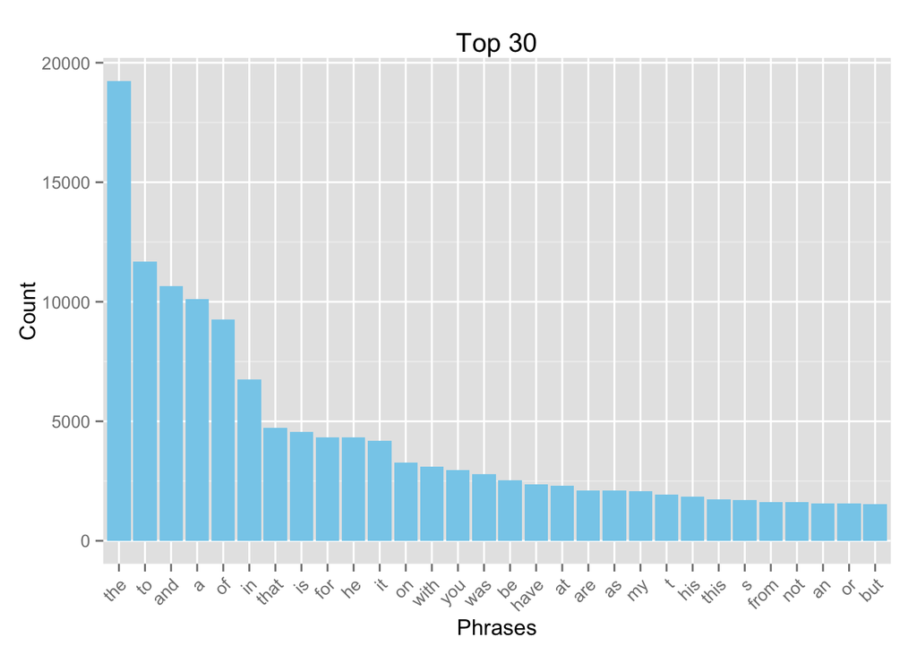

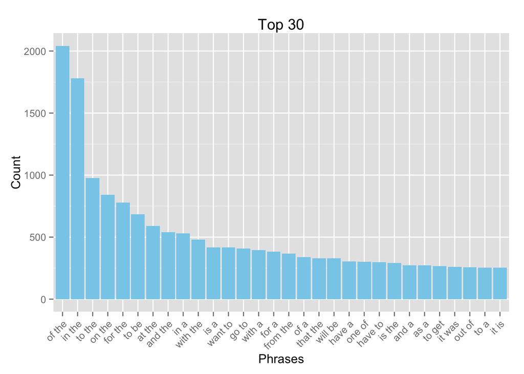

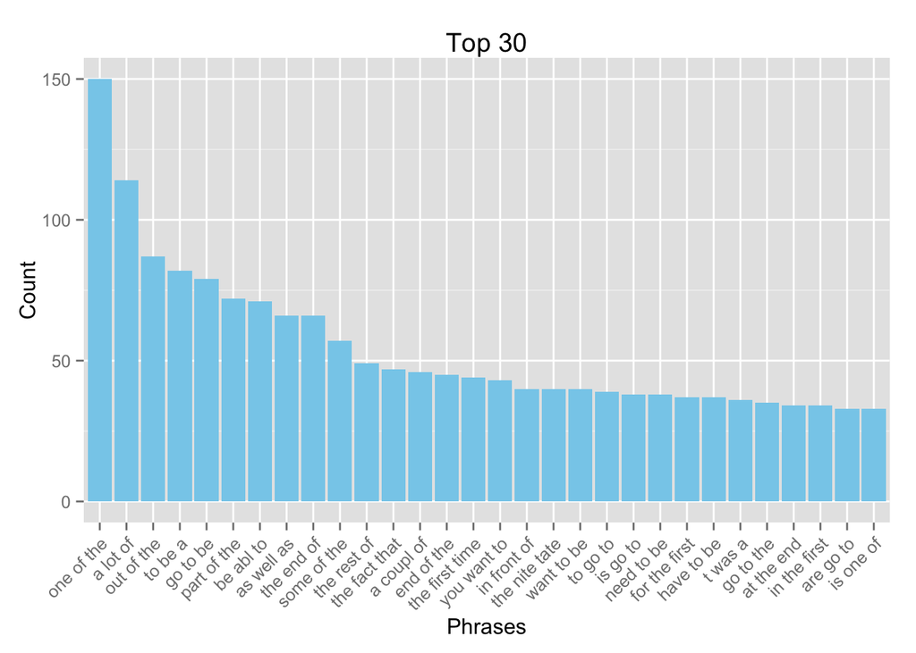

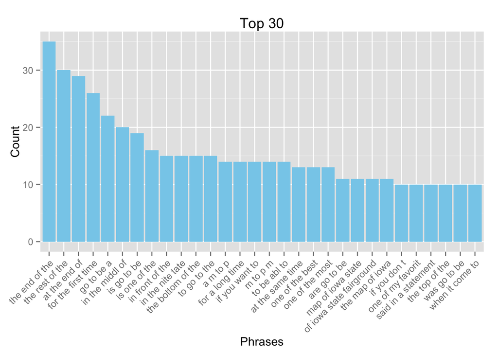

### Next Steps

This project requires to develop an online application with user-friendly interface using Shiny Server. To take the size and speed of the model into account, we will only implement 2 or 3 grams algorithm for our online application.

The shiny application should consider: 1. Detecting the nearest 1 to 3 words of users’ typing and taking them as the inputs of model. 2. Return the predictions of model to the user interface.